# Thailand Road Accident Deaths 2011-2020

This document contains analysis of “Thailand Road Accident Deaths 2011-2020”.

# Initialize environments & Set locale to Thai

```r
Sys.setlocale("LC_CTYPE", "thai")
```

```
[1] "Thai_Thailand.874"
```

```r
install.packages('tidyverse')
install.packages('janitor')
library(tidyverse)
library(readxl)
library(janitor)
```

# Import data file

To ensure that the data file can import without error, import all columns as text first. Then clean the column names using clean_names function

```r
data <- read_excel("data\\thailand-road-accident-deaths-2011-2020.xlsx", col_types = "text")
data <- clean_names(data)
```

[output not shown]

# Ensure proper data types

To ensure each of the column has proper data type. Create a new data frame `df` that mutate from `data` with proper data conversion. - for `sex` - Use recode function to convert to `Male` and `Female` - create a new column `datetime_rec` by combining `date_rec` and `time_rec`

```r
df <- data %>%
  mutate(id = as.numeric(id),
         dead_year_budha = as.numeric(dead_year_budha),
         dead_year = as.numeric(dead_year),
         age = as.numeric(age),
         sex = recode(sex,"1"  = "Male", "2" = "Female", .default = NA_character_, .missing = NA_character_),
         birth_year = as.numeric(birth_year),
         dead_date = as.Date(dead_date,"%Y-%m-%d"),
         datetime_rec = as.POSIXct(paste(date_rec, time_rec), format="%Y-%m-%d %H:%M:%S"),
         acc_lat = as.numeric(acc_lat),
         acc_long = as.numeric(acc_long)
  )
```

```
NAs introduced by coercionNAs introduced by coercionNAs introduced by coercion
```

# Explore data to see if there is any further cleaning steps required

## Each variables check

### id

#### Check if all the ids are unique

```r
n_occur <- data.frame(table(df$id))
n_occur[n_occur$Freq>1,]
```

| Var1 | Freq |
| --- | --- |

### dead_year_budha

Check of data distribution - as we expected only 10 different values

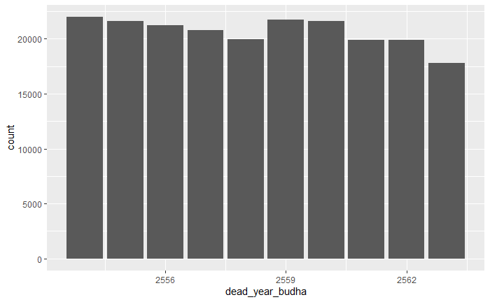

```r
ggplot(data = df) + geom_bar(mapping = aes(x=dead_year_budha))
```

### dead_year

Check of data distribution - as we expected only 10 different values

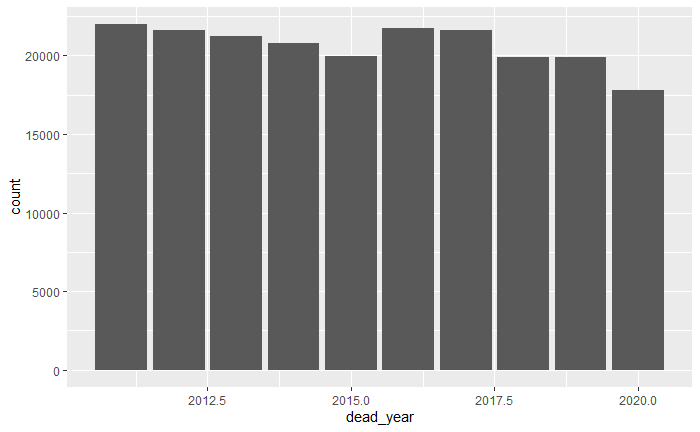

```r
ggplot(data = df) + geom_bar(mapping = aes(x=dead_year))
```

### age

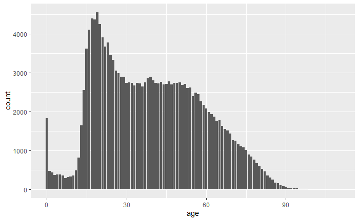

```r
ggplot(data = df) + geom_bar(mapping = aes(x=age))
```

#### Calculate % of Age’s NA

```r
n <- df %>% count()
n_age_na <- df %>% filter(is.na(age)) %>%  count()
age_na_pct <- n_age_na/n*100
```

#### There are about **14.270916 percents** of rows that doesn’t have age data () and also some of them are 0

- Where age==0 = is that mean these are infant with less than a year old? Possible.So age == 0 is valid value

```r
df %>% filter(age==0)
```

| id | dead_year_budha | dead_year | age | sex | birth_year | nationality_id | tumbol | district | province | risk_helmet | risk_safety_belt | dead_date | date_rec | time_rec | acc_sub_dist | acc_dist | acc_prov | acc_lat | acc_long | icd_10 | vehicle | datetime_rec |
| --- | --- | --- | --- | --- | --- | --- | --- | --- | --- | --- | --- | --- | --- | --- | --- | --- | --- | --- | --- | --- | --- | --- |
| 8596077 | 2554 | 2011 | 0 | Female | 2010 | 99 | โพธาราม | โพธาราม | รบ | NA | NA | 2011-03-21 | 2011-03-21 | 09:40:00 | หนองกระเจ็ด | บ้านลาด | ราชบุรี | 12.997798 | 99.94762 | V892 | ไม่ระบุพาหนะ | 2011-03-21 09:40:00 |
| 8597178 | 2554 | 2011 | 0 | Female | 2010 | 99 | ปอ | เวียงแก่น | ชร | NA | NA | 2011-03-26 | 2011-03-26 | 14:30:00 | ตับเต่า | เทิง | เชียงราย | NA | NA | V892 | ไม่ระบุพาหนะ | 2011-03-26 14:30:00 |
| 8598008 | 2554 | 2011 | 0 | Male | 2010 | 99 | คลองไทร | ท่าฉาง | สฎ | NA | NA | 2011-08-14 | 2011-08-14 | 17:30:00 | ทุ่งหลวง | ละแม | ชุมพร | 9.794926 | 99.07306 | V489 | รถยนต์ | 2011-08-14 17:30:00 |
| 8598239 | 2554 | 2011 | 0 | Male | 2011 | 99 | โนนตาล | ท่าอุเทน | นพ | NA | NA | 2011-09-21 | 2011-09-21 | 14:00:00 | NA | ท่าอุเทน | นครพนม | 17.549264 | 104.57895 | V536 | รถบรรทุกขนาดเล็ก/รถตู้ | 2011-09-21 14:00:00 |
| 8599738 | 2554 | 2011 | 0 | Male | 2011 | 99 | น้ำซึม | เมืองอุทัยธานี | อน | NA | NA | 2011-02-01 | 2011-01-26 | 15:30:00 | NA | ศรีประจันต์ | สุพรรณบุรี | 14.624264 | 100.14751 | V499 | รถยนต์ | 2011-01-26 15:30:00 |
| 8599745 | 2554 | 2011 | 0 | Male | 2011 | 99 | ทับช้าง | สอยดาว | จบ | NA | NA | 2011-10-22 | 2011-10-21 | 22:30:00 | มาบตาพุด | เมืองระยอง | ระยอง | NA | NA | V436 | รถยนต์ | 2011-10-21 22:30:00 |
| 8599838 | 2554 | 2011 | 0 | Male | 2011 | 99 | ลางา | มายอ | ปน | NA | NA | 2011-09-04 | 2011-09-03 | 21:30:00 | บานา | เมืองปัตตานี | ปัตตานี | 6.878192 | 101.26008 | V899 | ไม่ระบุพาหนะ | 2011-09-03 21:30:00 |
| 8600455 | 2554 | 2011 | 0 | Male | 2011 | 99 | ดอนไก่ดี | กระทุ่มแบน | สค | NA | NA | 2011-10-21 | 2011-10-20 | 00:04:00 | ตลาดกระทุ่มแบน | กระทุ่มแบน | สมุทรสาคร | 13.651892 | 100.25733 | V229 | รถจักรยานยนต์ | 2011-10-20 00:04:00 |
| 8600948 | 2554 | 2011 | 0 | Male | 2010 | 99 | NA | NA | NA | NA | NA | 2011-02-12 | NA | NA | NA | NA | ปราจีนบุรี | NA | NA | V499 | รถยนต์ |  |
| 8601431 | 2554 | 2011 | 0 | Female | 2011 | 99 | NA | NA | NA | NA | NA | 2011-09-12 | NA | NA | NA | NA | สงขลา | NA | NA | V892 | ไม่ระบุพาหนะ |  |

[output cut: 990 more lines]

```r
df %>% filter(birth_year-dead_year == 1)
```

| id | dead_year_budha | dead_year | age | sex | birth_year | nationality_id | tumbol | district | province | risk_helmet | risk_safety_belt | dead_date | date_rec | time_rec | acc_sub_dist | acc_dist | acc_prov | acc_lat | acc_long | icd_10 | vehicle | datetime_rec |
| --- | --- | --- | --- | --- | --- | --- | --- | --- | --- | --- | --- | --- | --- | --- | --- | --- | --- | --- | --- | --- | --- | --- |
| 8629047 | 2555 | 2012 | 0 | Male | 2013 | NA | หล่มสัก | หล่มสัก | พช | NA | NA | 2012-12-22 | 2012-12-22 | 23:30:00 | ตาลเดี่ยว | หล่มสัก | เพชรบูรณ์ | 16.788557 | 101.25869 | NA | ไม่ระบุพาหนะ | 2012-12-22 23:30:00 |
| 8631055 | 2555 | 2012 | 0 | Male | 2013 | NA | ผาขาว | ผาขาว | ลย | ไม่มี | NA | 2012-12-17 | 2012-12-17 | 15:00:00 | ผาขาว | ผาขาว | เลย | 17.020648 | 101.94862 | NA | ไม่ระบุพาหนะ | 2012-12-17 15:00:00 |
| 8648928 | 2556 | 2013 | 0 | Male | 2014 | NA | NA | NA | NA | NA | NA | 2013-10-30 | 2013-10-30 | 06:15:00 | ฉิมพลี | ตลิ่งชัน | กรุงเทพมหานคร | 13.781212 | 100.42464 | NA | ไม่ระบุพาหนะ | 2013-10-30 06:15:00 |
| 8648955 | 2556 | 2013 | 0 | Male | 2014 | NA | NA | NA | NA | NA | NA | 2013-12-31 | 2013-12-31 | 21:56:00 | ห้วยหม้าย | สอง | แพร่ | 18.438875 | 100.16565 | NA | ไม่ระบุพาหนะ | 2013-12-31 21:56:00 |
| 8648990 | 2556 | 2013 | 0 | Male | 2014 | NA | NA | NA | NA | NA | NA | 2013-12-31 | 2013-12-31 | 17:30:00 | ศาลเจ้าโรงทอง | วิเศษชัยชาญ | อ่างทอง | 14.611890 | 100.33817 | NA | ไม่ระบุพาหนะ | 2013-12-31 17:30:00 |
| 8651891 | 2556 | 2013 | 0 | Male | 2014 | NA | NA | NA | NA | NA | NA | 2013-12-17 | 2013-12-17 | 19:30:00 | บางเสาธง | บางเสาธง | สมุทรปราการ | 13.564549 | 100.79302 | NA | ไม่ระบุพาหนะ | 2013-12-17 19:30:00 |
| 8651905 | 2556 | 2013 | 0 | Male | 2014 | NA | NA | NA | NA | NA | NA | 2013-12-31 | 2013-12-31 | 23:50:00 | สีสุก | จักราช | นครราชสีมา | 14.865890 | 102.37518 | NA | ไม่ระบุพาหนะ | 2013-12-31 23:50:00 |
| 8651906 | 2556 | 2013 | 0 | Female | 2014 | NA | โคกกลาง | ประทาย | นม | NA | NA | 2013-12-30 | 2013-12-30 | 08:50:00 | โคกกลาง | ประทาย | นครราชสีมา | 15.468472 | 102.75142 | NA | ไม่ระบุพาหนะ | 2013-12-30 08:50:00 |
| 8651936 | 2556 | 2013 | 0 | Male | 2014 | NA | คมบาง | เมืองจันทบุรี | จบ | NA | NA | 2013-12-31 | 2013-12-30 | 17:00:00 | คลองพลู | เขาคิชฌกูฎ | จันทบุรี | 12.935628 | 102.01835 | NA | ไม่ระบุพาหนะ | 2013-12-30 17:00:00 |
| 8651942 | 2556 | 2013 | 0 | Male | 2014 | NA | NA | NA | NA | NA | NA | 2013-12-27 | 2013-12-27 | 20:30:00 | รังสิต | ธัญบุรี | ปทุมธานี | 14.019229 | 100.73233 | NA | ไม่ระบุพาหนะ | 2013-12-27 20:30:00 |

[output cut: 76 more lines]

```r
df %>% filter((birth_year-dead_year == 1) | (birth_year == dead_year)) %>% filter(age==0)
```

| id | dead_year_budha | dead_year | age | sex | birth_year | nationality_id | tumbol | district | province | risk_helmet | risk_safety_belt | dead_date | date_rec | time_rec | acc_sub_dist | acc_dist | acc_prov | acc_lat | acc_long | icd_10 | vehicle | datetime_rec |
| --- | --- | --- | --- | --- | --- | --- | --- | --- | --- | --- | --- | --- | --- | --- | --- | --- | --- | --- | --- | --- | --- | --- |
| 8598239 | 2554 | 2011 | 0 | Male | 2011 | 99 | โนนตาล | ท่าอุเทน | นพ | NA | NA | 2011-09-21 | 2011-09-21 | 14:00:00 | NA | ท่าอุเทน | นครพนม | 17.549264 | 104.57895 | V536 | รถบรรทุกขนาดเล็ก/รถตู้ | 2011-09-21 14:00:00 |
| 8599738 | 2554 | 2011 | 0 | Male | 2011 | 99 | น้ำซึม | เมืองอุทัยธานี | อน | NA | NA | 2011-02-01 | 2011-01-26 | 15:30:00 | NA | ศรีประจันต์ | สุพรรณบุรี | 14.624264 | 100.14751 | V499 | รถยนต์ | 2011-01-26 15:30:00 |
| 8599745 | 2554 | 2011 | 0 | Male | 2011 | 99 | ทับช้าง | สอยดาว | จบ | NA | NA | 2011-10-22 | 2011-10-21 | 22:30:00 | มาบตาพุด | เมืองระยอง | ระยอง | NA | NA | V436 | รถยนต์ | 2011-10-21 22:30:00 |
| 8599838 | 2554 | 2011 | 0 | Male | 2011 | 99 | ลางา | มายอ | ปน | NA | NA | 2011-09-04 | 2011-09-03 | 21:30:00 | บานา | เมืองปัตตานี | ปัตตานี | 6.878192 | 101.26008 | V899 | ไม่ระบุพาหนะ | 2011-09-03 21:30:00 |
| 8600455 | 2554 | 2011 | 0 | Male | 2011 | 99 | ดอนไก่ดี | กระทุ่มแบน | สค | NA | NA | 2011-10-21 | 2011-10-20 | 00:04:00 | ตลาดกระทุ่มแบน | กระทุ่มแบน | สมุทรสาคร | 13.651892 | 100.25733 | V229 | รถจักรยานยนต์ | 2011-10-20 00:04:00 |
| 8601431 | 2554 | 2011 | 0 | Female | 2011 | 99 | NA | NA | NA | NA | NA | 2011-09-12 | NA | NA | NA | NA | สงขลา | NA | NA | V892 | ไม่ระบุพาหนะ |  |
| 8602660 | 2554 | 2011 | 0 | Male | 2011 | 99 | NA | NA | NA | NA | NA | 2011-11-13 | NA | NA | NA | NA | ชุมพร | NA | NA | V892 | ไม่ระบุพาหนะ |  |
| 8603448 | 2554 | 2011 | 0 | Male | 2011 | NA | โพนงาม | กมลาไสย | กส | NA | NA | 2011-10-29 | 2011-10-29 | 10:18:00 | หนองโก | บรบือ | มหาสารคาม | 16.066168 | 103.21916 | NA | ไม่ระบุพาหนะ | 2011-10-29 10:18:00 |
| 8603715 | 2554 | 2011 | 0 | Male | 2011 | NA | โคกไทย | ศรีมโหสถ | ปจ | NA | NA | 2011-06-30 | 2011-06-30 | 20:00:00 | โคกปีบ | ศรีมโหสถ | ปราจีนบุรี | NA | NA | NA | ไม่ระบุพาหนะ | 2011-06-30 20:00:00 |
| 8607491 | 2554 | 2011 | 0 | Female | 2011 | NA | NA | NA | NA | NA | NA | 2011-03-01 | NA | NA | NA | NA | สระบุรี | NA | NA | NA | ไม่ระบุพาหนะ |  |

[output cut: 990 more lines]

### sex

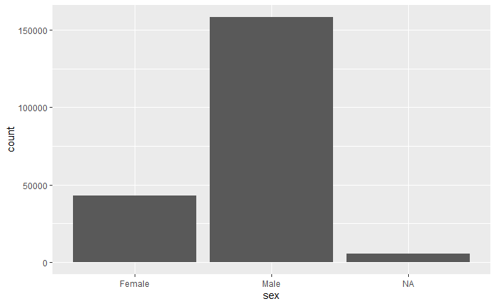

```r
ggplot(data = df) + geom_bar(mapping = aes(x=sex))
```

### birth_year

[figure not shown]

```r
ggplot(data = df2) + geom_bar(mapping = aes(x=birth_year))
```

```r
str(df)
```

```
tibble [206,588 x 23] (S3: tbl_df/tbl/data.frame)
 $ id              : num [1:206588] 8594771 8594772 8594773 8594774 8594775 ...
 $ dead_year_budha : num [1:206588] 2554 2554 2554 2554 2554 ...
 $ dead_year       : num [1:206588] 2011 2011 2011 2011 2011 ...
 $ age             : num [1:206588] 21 23 26 16 12 17 16 40 40 29 ...
 $ sex             : chr [1:206588] "Male" "Male" "Male" "Male" ...
 $ birth_year      : num [1:206588] 1989 1987 1984 1994 1998 ...
 $ nationality_id  : chr [1:206588] "99" "99" "99" "99" ...
 $ tumbol          : chr [1:206588] "บึงสามพัน" "พังกาญจน์" "จำปาโมง" "ปลักแรด" ...
 $ district        : chr [1:206588] "บึงสามพัน" "พนม" "บ้านผือ" "บางระกำ" ...
 $ province        : chr [1:206588] "พช" "สฎ" "อด" "พล" ...
 $ risk_helmet     : chr [1:206588] NA NA NA NA ...
 $ risk_safety_belt: chr [1:206588] NA NA NA NA ...
 $ dead_date       : Date[1:206588], format: "2011-01-01" "2011-01-01" "2011-01-01" "2011-01-01" ...
 $ date_rec        : chr [1:206588] "2011-01-01" "2011-01-01" "2011-01-01" "2011-01-01" ...
 $ time_rec        : chr [1:206588] "00:25:00" "06:35:00" "19:00:00" "02:00:00" ...
 $ acc_sub_dist    : chr [1:206588] "บึงสามพัน" "พังกาญจน์" "บ้านฉาง" "ปลักแรด" ...
 $ acc_dist        : chr [1:206588] "บึงสามพัน" "พนม" "บ้านฉาง" "บางระกำ" ...
 $ acc_prov        : chr [1:206588] "เพชรบูรณ์" "สุราษฎร์ธานี" "ระยอง" "พิษณุโลก" ...
 $ acc_lat         : num [1:206588] 15.79 8.92 NA 16.66 16.66 ...
 $ acc_long        : num [1:206588] 101 98.9 NA 100.1 100.1 ...
 $ icd_10          : chr [1:206588] "V892" "V299" "V234" "V429" ...
 $ vehicle         : chr [1:206588] "ไม่ระบุพาหนะ" "รถจักรยานยนต์" "รถจักรยานยนต์" "รถยนต์" ...
 $ datetime_rec    : POSIXct[1:206588], format: "2011-01-01 00:25:00" "2011-01-01 06:35:00" "2011-01-01 19:00:00" "2011-01-01 02:00:00" ...
```